# Mixed Models Practice: Effects on Quadrat Richness

C. M. Ciafre

September 23, 2019

### Background

I collected plant species data from 24 wetland sites across the Eastern Highland Rim ecoregion once in early summer and once in late summer. Each site was subsampled with a varying number of 1 m^2 quadrats, resulting in a total of 999 subsample units.

Fixed effects:  
-Sampling season (early or late)  
-Water permanence status (ephemeral or permanent)  
-Site radius (continuous, in meters)

Random effects:  
-Plot  
-Quadrat (nested within plot)

This is a nested, uncrossed model.

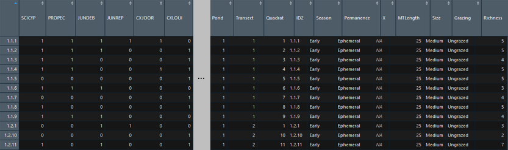

Abbreviated sample of data, including a species presence/absence matrix by quadrat and variables used for the analysis; 563 columns and 987 rows not shown.

### Visualizing trends in the data

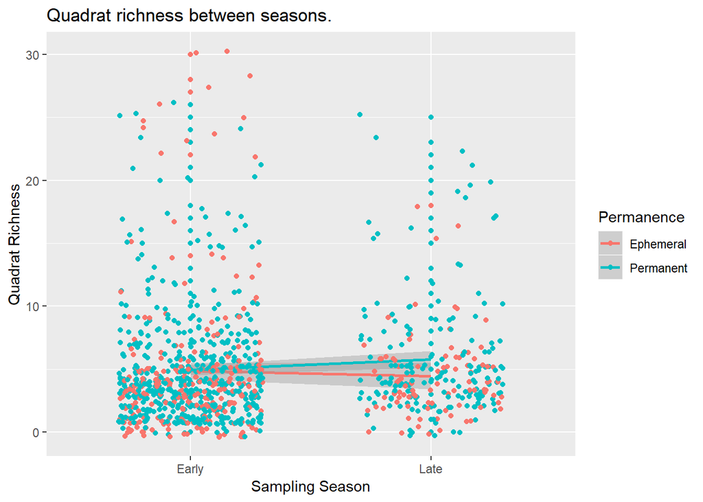

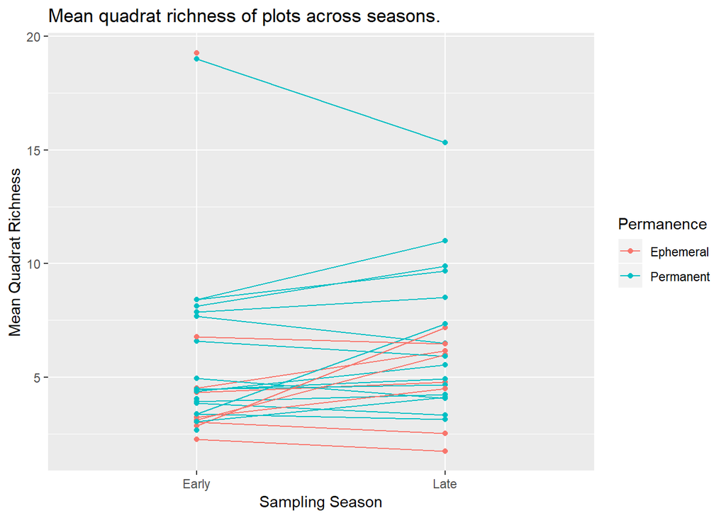

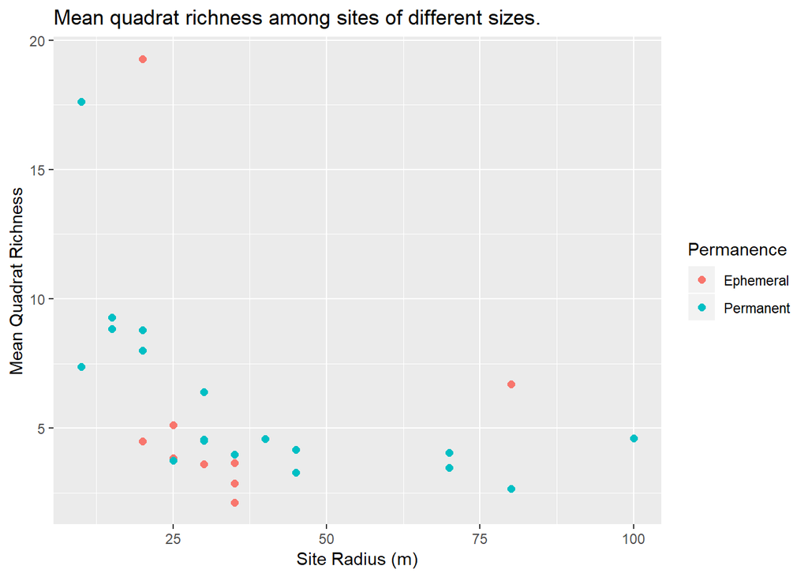

### Making the models

```r
#Fully crossed
model1<-lmer(Richness~Permanence+MTLength+Season+Permanence:MTLength+MTLength:Season+Season:Permanence+Permanence:MTLength:Season+(1|Pond:Quadrat), data= mergedcommat)

#All fixed variables but with Permanence:Size interaction only
model2<-lmer(Richness~Permanence+MTLength+Season+Permanence:MTLength+(1|Pond:Quadrat), data= mergedcommat)

#model2 without Season
model4<-lmer(Richness~Permanence+MTLength+Permanence:MTLength+(1|Pond:Quadrat), data= mergedcommat)
```

|  | Df | AIC | BIC | logLik | deviance | Chisq | Chi Df | Pr(>Chisq) |
| --- | --- | --- | --- | --- | --- | --- | --- | --- |
| model2 | 7 | 5680.888 | 5715.236 | -2833.444 | 5666.888 | NA | NA | NA |
| model1 | 10 | 5686.123 | 5735.190 | -2833.061 | 5666.123 | 0.7655214 | 3 | 0.8576948 |

Model 2 did not significantly differ from model 1 (p=0.8576948) and it has a lower AIC score, so it is likely that the discarded interactions (MTLength:Season, Season:Permanence, and Permanence:MTLength:Season) were unimportant to the model.

|  | Df | AIC | BIC | logLik | deviance | Chisq | Chi Df | Pr(>Chisq) |
| --- | --- | --- | --- | --- | --- | --- | --- | --- |
| model4 | 6 | 5685.417 | 5714.857 | -2836.708 | 5673.417 | NA | NA | NA |
| model2 | 7 | 5680.888 | 5715.236 | -2833.444 | 5666.888 | 6.528332 | 1 | 0.0106169 |

Because I was interested in whether quadrat richness changed between sampling season, I removed that term from model 2. Because model 4 significantly differed from model 2 (p=0.0106169), and because it has a higher AIC score, sampling season is likely important to the model and should be retained.

With the current data and variables, the best model is model 2:  
Richness~Permanence+MTLength+Season+Permanence:MTLength+(1|Pond:Quadrat)